# Intro to SciPy stats

The module 'stats' form SciPy includes all the required methods for statistical analyses, from generating values that comply with one of its 91 included probability distributions to perform a statistical tests or fitting data to them.

The mechanics to use the included probability distributions are easy, pick your distribution and then for each distribution you will have a set of methods that will allow you to query the information from it:

rvs -> Random values from the underlying distribution

pdf -> Probability density function. The probability of a particular value being obtained from that distribution

cdf -> Cumulative distribution function. the probability of thhat value or below being obtained from that distribution (for continuous distributions)

pmf -> Prabability mass function -> The probability of the having that value in a discrete distribution

ppf -> Percentile point function (i.e. CDF inverse). The value of the variate for which the cumulative probability has the given value

sf -> Survival function. The probability of the value or greater (1-cdf)

isf - Inverse of the survival function. It gives the value of the variate for which the survival function has the given value.

stats -> Mean, variance, skew, or kurtosis

## Exmaples of distributions included:

[output not shown]

## Frozen vs. general form

Distributions have a "frozen" form and a general form.

The general form is stateless: You call a class method and supply the distribution parameters as arguments to every call.

The frozen form creates an object with the distribution parameters set and as such you don't need to pass the parameters every time.

```python
%matplotlib inline

import pandas as pd
import numpy as np
import matplotlib.pyplot as plt
import scipy.stats as stats
```

### Normal distribution

```python
# generate a normal distribution object and assign it to a variable
dist = stats.norm(loc=1,scale=4)
```

```python
dist
```

```
<scipy.stats._distn_infrastructure.rv_frozen at 0x11a819630>
```

```python
dist.mean(), dist.std()
```

```
(1.0, 4.0)
```

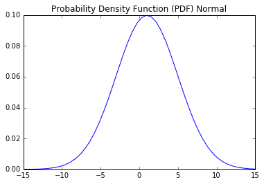

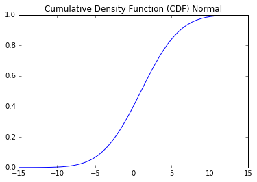

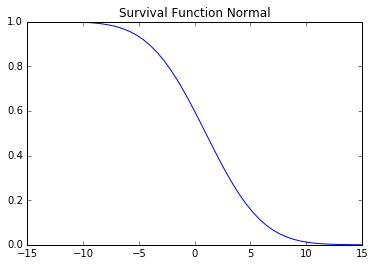

```python
x = np.linspace(-15,15)
plt.plot(x, dist.pdf(x))
plt.title('Probability Density Function (PDF) Normal')

plt.figure()
plt.plot(x, dist.cdf(x))
plt.title('Cumulative Density Function (CDF) Normal')

plt.figure()
plt.plot(x, dist.sf(x))
plt.title('Survival Function Normal')

plt.show()
```

Using general form vs. frozen form :

```python
temp1 = stats.norm.cdf(x=2.5,
                  loc=1,
                  scale=4)

temp2 = dist.cdf(2.5)

print(temp1-temp2)
```

```
0.0
```

Finding Quantiles in a normal distribution

```python
print( dist.ppf(q=0.025) ) # Find the quantile for the 2.5% cutoff

print( dist.ppf(q=0.975) ) # Find the quantile for the 97.5% cutoff
```

```
-6.83985593816
8.83985593816
```

### Uniform distribution

The uniform distribution is a probability distribution where each value within a certain range is equally likely to occur and values outside of the range never occur

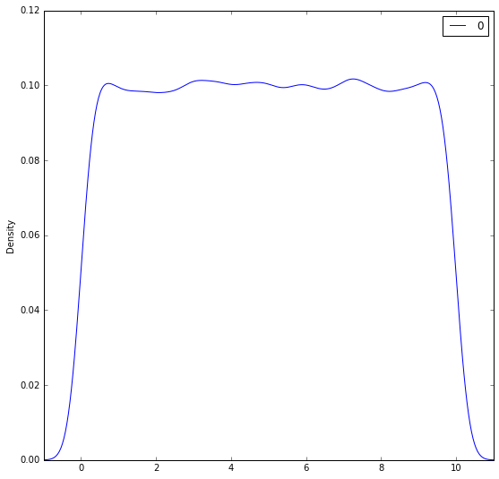

```python
data = stats.uniform.rvs(size=100000,
                                 loc = 0,
                                 scale=10)

pd.DataFrame(data).plot(kind="density",  # Plot the distribution
                               figsize=(9,9),
                               xlim=(-1,11))
```

### Binomial Distribution

The binomial distribution is a discrete probability distribution that models the outcomes of a given number of random trails of some experiment or event.

The binomial is defined by two parameters: the probability of success in any given trial and the number of trials.

The binomial distribution tells you how likely it is to achieve a given number of successes in n trials of the experiment

For example imagine we throw a coin 150 and we get 4 heads... is the coin fair? What is the probability of that happening?

```python
# Is the coin fair?

dist = stats.binom(n=150,p=0.5)
dist.pmf(k=4)
```

```
1.4195346122150675e-38
```

### Geometric and Exponential distributions

The geometric and exponential distributions model what it takes for an event to occur either in tries or time.

The geometric distribution is discrete and models the number of trials it takes to achieve a success in repeated experiments with a given probability of success.

The exponential distribution is a continuous analog of the geometric distribution and models the amount of time you have to wait before an event occurs given a certain occurrence rate.

```
col_0     1    2   3   4   5  6  7  9
row_0
counts  234  128  71  36  20  4  6  1
```

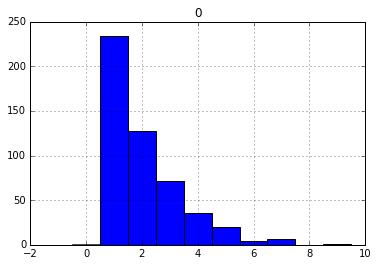

```python
random.seed(765)

values_geom = stats.geom.rvs(size=500,p=0.5)

# Print table of counts
print( pd.crosstab(index="counts", columns= values_geom))

# Plot histogram
pd.DataFrame(values_geom).hist(range=(-0.5,max(values_geom)+0.5)
                                    , bins=max(values_geom)+1)
plt.show()
```

```python
#If I need 9 flips to see a head... should I play the lottery?
stats.geom.pmf(k=9,
              p=0.5)
```

```
0.001953125
```

### Poisson distribution

The Poisson distribution models the probability of seeing a certain number of successes within a time interval, where the time it takes for the next success is modeled by an exponential distribution.

```
col_0     0     1     2     3    4    5    6   7   8   9   10
row_0
counts  1367  2713  2686  1837  869  368  117  32   6   2   3
```

```
array([[<matplotlib.axes._subplots.AxesSubplot object at 0x11a82a2b0>]], dtype=object)
```

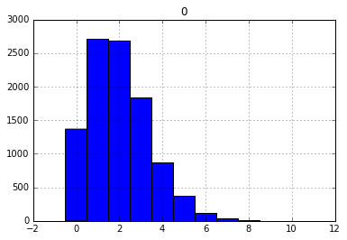

```python
random.seed(12)

arrival_rate_1 = stats.poisson.rvs(size=10000,  # Generate Poisson data
                                   mu=2 )       # Average arrival time 1

# Print table of counts
print( pd.crosstab(index="counts", columns= arrival_rate_1))

# Plot histogram
pd.DataFrame(arrival_rate_1).hist(range=(-0.5,max(arrival_rate_1)+0.5)
                                    , bins=max(arrival_rate_1)+1)
```

If I work at Do eat and people arrive at 10 per unit, how probable is having more than 16?

```python
1-stats.poisson.cdf(k=16,mu=10)
```

```
0.027041609784801079
```

If one day I have 25 arrival in that period, should I play the lottery?...

```python
stats.poisson.pmf(k=25,     mu=10)
```

```
2.9269109009328823e-05
```

### Fat-tailed distribution

Let's have a look at a fat-tailed distribution now. A pareto distribution is defined as

\begin{equation} f(x) = b x^{-(b+1)}, \ \ b>0, \ \ x \geq 1 \end{equation}

In this case, we will need to specify the parameter b when we generate the distribution object.

Let's generate three frozen pareto distribution objects with different $b$ parameters.

```python
pareto_1 = stats.pareto(b=1.0)
pareto_2 = stats.pareto(b=2.0)
pareto_3 = stats.pareto(b=3.0)

print (pareto_1.mean(), pareto_1.std())
print (pareto_2.mean(), pareto_2.std())
print (pareto_3.mean(), pareto_3.std())
```

```
inf inf
2.0 inf
1.5 0.866025403784
```

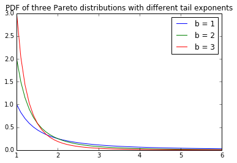

```python
x = np.linspace(1,6)

plt.plot(x, pareto_1.pdf(x), label='b = 1')
plt.plot(x, pareto_2.pdf(x), label='b = 2')
plt.plot(x, pareto_3.pdf(x), label='b = 3')
plt.title('PDF of three Pareto distributions with different tail exponents')
plt.legend()
```

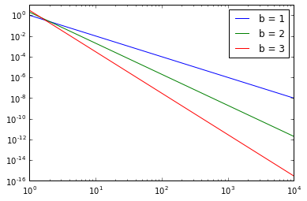

```python
x = np.linspace(1,10000,1000000)

plt.loglog(x, pareto_1.pdf(x), label='b = 1')
plt.loglog(x, pareto_2.pdf(x), label='b = 2')
plt.loglog(x, pareto_3.pdf(x), label='b = 3')
plt.legend()
```

## Fitting Data

In addition to generating a "frozen" dsitribution, we can find the parameters that best fit a model to data using the `fit()` function of a given distribution. The `fit()` function uses maximum-likelihood estimation (MLE). It is often convenient to generate a frozen distribution with the fitted parameters.

```python
# generate some data from a normal distribution with mean 0 and variance 1
norm_data = stats.norm.rvs(size=1000)
```

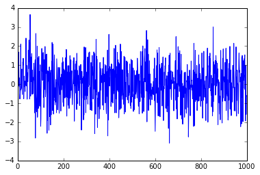

```python
plt.plot(norm_data)
```

```python
norm_parameter_fit = stats.norm.fit(norm_data)
```

```python
norm_parameter_fit
```

```
(0.026422208627241161, 1.0002793237822059)
```

```python
#generate a frozen distribution with fitted location and scale parameters
fitted_norm = stats.norm(loc=norm_parameter_fit[0], scale=norm_parameter_fit[1])
```

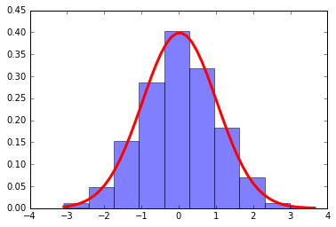

```python
x = np.linspace(norm_data.min(), norm_data.max())
plt.hist(norm_data, normed=True, alpha=0.5)
plt.plot(x, fitted_norm.pdf(x), 'r', lw=3)
```

```
(-0.048007364784077175, 2.2665575034663159)
```

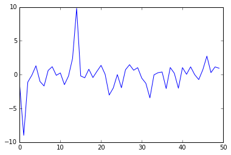

```python
t_data = stats.t.rvs(df=2,size=50)
plt.plot(t_data)

norm_parameter_fit_2 = stats.norm.fit(t_data)
norm_parameter_fit_2
```

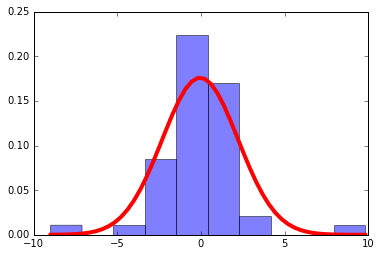

```python
fitted_norm_2 = stats.norm(loc=norm_parameter_fit_2[0], scale=norm_parameter_fit_2[1])

x = np.linspace(t_data.min(), t_data.max())

plt.hist(t_data, normed=True, alpha=0.5)
plt.plot(x, fitted_norm_2.pdf(x), 'r', lw=4)
```

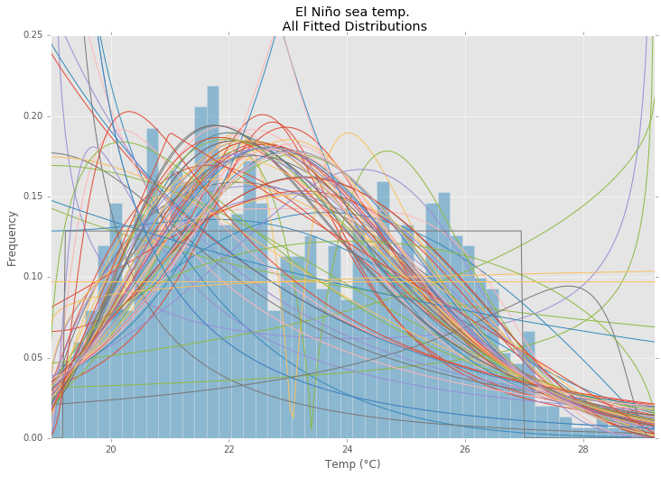

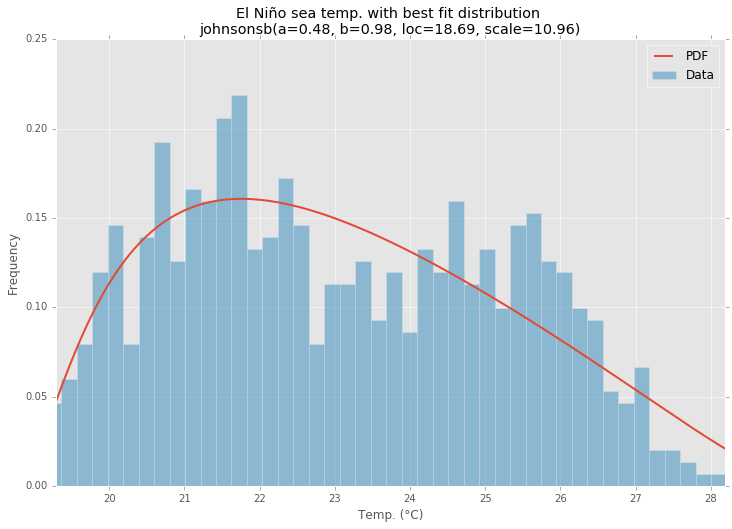

```python
import warnings
import numpy as np
import pandas as pd
import scipy.stats as st
import statsmodels as sm
import matplotlib
import matplotlib.pyplot as plt

matplotlib.rcParams['figure.figsize'] = (16.0, 12.0)
matplotlib.style.use('ggplot')

# Create models from data
def best_fit_distribution(data, bins=200, ax=None):
    """Model data by finding best fit distribution to data"""
    # Get histogram of original data
    y, x = np.histogram(data, bins=bins, normed=True)
    x = (x + np.roll(x, -1))[:-1] / 2.0

    # Distributions to check
    DISTRIBUTIONS = [
        st.alpha,st.anglit,st.arcsine,st.beta,st.betaprime,st.bradford,st.burr,st.cauchy,st.chi,st.chi2,st.cosine,
        st.dgamma,st.dweibull,st.erlang,st.expon,st.exponnorm,st.exponweib,st.exponpow,st.f,st.fatiguelife,st.fisk,
        st.foldcauchy,st.foldnorm,st.frechet_r,st.frechet_l,st.genlogistic,st.genpareto,st.gennorm,st.genexpon,
        st.genextreme,st.gausshyper,st.gamma,st.gengamma,st.genhalflogistic,st.gilbrat,st.gompertz,st.gumbel_r,
        st.gumbel_l,st.halfcauchy,st.halflogistic,st.halfnorm,st.halfgennorm,st.hypsecant,st.invgamma,st.invgauss,
        st.invweibull,st.johnsonsb,st.johnsonsu,st.ksone,st.kstwobign,st.laplace,st.levy,st.levy_l,st.levy_stable,
        st.logistic,st.loggamma,st.loglaplace,st.lognorm,st.lomax,st.maxwell,st.mielke,st.nakagami,st.ncx2,st.ncf,
        st.nct,st.norm,st.pareto,st.pearson3,st.powerlaw,st.powerlognorm,st.powernorm,st.rdist,st.reciprocal,
        st.rayleigh,st.rice,st.recipinvgauss,st.semicircular,st.t,st.triang,st.truncexpon,st.truncnorm,st.tukeylambda,
        st.uniform,st.vonmises,st.vonmises_line,st.wald,st.weibull_min,st.weibull_max,st.wrapcauchy
    ]

    # Best holders
    best_distribution = st.norm
    best_params = (0.0, 1.0)
    best_sse = np.inf

    # Estimate distribution parameters from data
    for distribution in DISTRIBUTIONS:

        # Try to fit the distribution
        try:
            # Ignore warnings from data that can't be fit
            with warnings.catch_warnings():
                warnings.filterwarnings('ignore')

                # fit dist to data
                params = distribution.fit(data)

                # Separate parts of parameters
                arg = params[:-2]
                loc = params[-2]
                scale = params[-1]

                # Calculate fitted PDF and error with fit in distribution
                pdf = distribution.pdf(x, loc=loc, scale=scale, *arg)
                sse = np.sum(np.power(y - pdf, 2.0))

                # if axis pass in add to plot
                try:
                    if ax:
                        pd.Series(pdf, x).plot(ax=ax)
                    end
                except Exception:
                    pass

                # identify if this distribution is better
                if best_sse > sse > 0:
                    best_distribution = distribution
                    best_params = params
                    best_sse = sse

        except Exception:
            pass

    return (best_distribution.name, best_params)

def make_pdf(dist, params, size=10000):
    """Generate distributions's Propbability Distribution Function """

    # Separate parts of parameters
    arg = params[:-2]
    loc = params[-2]
    scale = params[-1]

    # Get sane start and end points of distribution
    start = dist.ppf(0.01, *arg, loc=loc, scale=scale) if arg else dist.ppf(0.01, loc=loc, scale=scale)
    end = dist.ppf(0.99, *arg, loc=loc, scale=scale) if arg else dist.ppf(0.99, loc=loc, scale=scale)

    # Build PDF and turn into pandas Series
    x = np.linspace(start, end, size)
    y = dist.pdf(x, loc=loc, scale=scale, *arg)
    pdf = pd.Series(y, x)

    return pdf

# Load data from statsmodels datasets
data = pd.Series(sm.datasets.elnino.load_pandas().data.set_index('YEAR').values.ravel())

# Plot for comparison
plt.figure(figsize=(12,8))
ax = data.plot(kind='hist', bins=50, normed=True, alpha=0.5, color=plt.rcParams['axes.color_cycle'][1])
# Save plot limits
dataYLim = ax.get_ylim()

# Find best fit distribution
best_fit_name, best_fir_paramms = best_fit_distribution(data, 200, ax)
best_dist = getattr(st, best_fit_name)

# Update plots
ax.set_ylim(dataYLim)
ax.set_title(u'El Niño sea temp.\n All Fitted Distributions')
ax.set_xlabel(u'Temp (°C)')
ax.set_ylabel('Frequency')

# Make PDF
pdf = make_pdf(best_dist, best_fir_paramms)

# Display
plt.figure(figsize=(12,8))
ax = pdf.plot(lw=2, label='PDF', legend=True)
data.plot(kind='hist', bins=50, normed=True, alpha=0.5, label='Data', legend=True, ax=ax)

param_names = (best_dist.shapes + ', loc, scale').split(', ') if best_dist.shapes else ['loc', 'scale']
param_str = ', '.join(['{}={:0.2f}'.format(k,v) for k,v in zip(param_names, best_fir_paramms)])
dist_str = '{}({})'.format(best_fit_name, param_str)

ax.set_title(u'El Niño sea temp. with best fit distribution \n' + dist_str)
ax.set_xlabel(u'Temp. (°C)')
ax.set_ylabel('Frequency')
```

Example

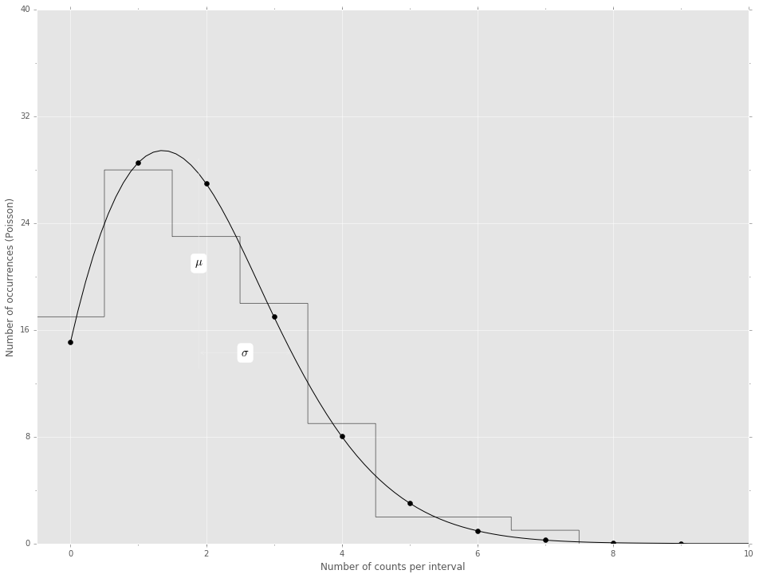

```python
import scipy as sp
from scipy import stats
from matplotlib import pyplot as plt
from scipy import interpolate

def simulate_poisson():
    # Mean is 1.89
    mu = 1.89
    sigma = sp.sqrt(mu)
    mu_plus_sigma = mu + sigma

    # Draw random samples from the Poisson distribution, to simulate
    # the observed events per interval.
    counts = stats.poisson.rvs(mu, size=100)

    # Bins for the histogram: only the last bin is closed on both
    # sides. We need one more bin than the maximum value of count, so
    # that the maximum value goes in its own bin instead of getting
    # added to the previous bin.
    # [0,1), [1, 2), ..., [max(counts), max(counts)+1]
    bins = range(0, max(counts)+2)

    # Plot histogram.
    plt.hist(counts, bins=bins, align="left", histtype="step", color="black")

    # Create Poisson distribution for given mu.
    x = range(0,10)
    prob = stats.poisson.pmf(x, mu)*100

    # Plot the PMF.
    plt.plot(x, prob, "o", color="black")

    # Draw a smooth curve through the PMF.
    l = sp.linspace(0,11,100)
    s = interpolate.spline(x, prob, l)
    plt.plot(l,s,color="black")

    plt.xlabel("Number of counts per interval")
    plt.ylabel("Number of occurrences (Poisson)")

    # Interpolated probability at x = μ + σ; for marking σ in the graph.
    xx = sp.searchsorted(l,mu_plus_sigma) - 1
    v = ((s[xx+1] -  s[xx])/(l[xx+1]-l[xx])) * (mu_plus_sigma - l[xx])
    v += s[xx]

    ax = plt.gca()
    # Reset axis range and ticks.
    ax.axis([-0.5,10, 0, 40])
    ax.set_xticks(range(1,10), minor=True)
    ax.set_yticks(range(0,41,8))
    ax.set_yticks(range(4,41,8), minor=True)

    # Draw arrow and then place an opaque box with μ in it.
    ax.annotate("", xy=(mu,29), xycoords="data", xytext=(mu, 13),
                textcoords="data", arrowprops=dict(arrowstyle="->",
                                                   connectionstyle="arc3"))
    bbox_props = dict(boxstyle="round", fc="w", ec="w")
    ax.text(mu, 21, r"$\mu$", va="center", ha="center",
            size=15, bbox=bbox_props)

    # Draw arrow and then place an opaque box with σ in it.
    ax.annotate("", xy=(mu,v), xytext=(mu_plus_sigma,v),
                arrowprops=dict(arrowstyle="<->", connectionstyle="arc3"))
    bbox_props = dict(boxstyle="round", fc="w", ec="w")
    ax.text(mu+(sigma/2.0), v, r"$\sigma$", va="center", ha="center",
            size=15, bbox=bbox_props)

    # Refresh plot and save figure.
    plt.draw()

simulate_poisson()
```

### Statistical Tests

The scipy.stats module offers 1-sample, two-sample unpaired and paired t-tests to help us uncover insights from our data

We use the **1-sample** test when we want to compare our data vs. a value to see if they differ statistically (for example the conversion rate of our site is assumed to be 8.3% but we have the following measures for a couple of days)

```python
data = [0.075, 0.077, 0.093, 0.081, 0.084, 0.077, 0.075, 0.072, 0.067]

one_t = stats.ttest_1samp(data, 0.083)

print("The t-statistic is %.3f and the p-value is %.3f." % one_t)
```

```
The t-statistic is -2.052 and the p-value is 0.074.
```

We use the **two-sample unpaired** to compare two unrelated samples (samples from independent distributions) to see if they differ.

In the example below data was collected on the average grade of 8 female students and 8 male students. We are interested in whether the average grade of these two samples is different

```python
female = [63.8, 56.4, 55.2, 58.5, 64.0, 51.6, 54.6, 71.0]
male = [75.5, 83.9, 75.7, 72.5, 56.2, 73.4, 67.7, 87.9]

two_sample = stats.ttest_ind(male, female)

print ("The t-statistic is %.3f and the p-value is %.3f." % two_sample)

# If we assume unequal population variances then we canuse Welch’s t-test by setting the equal_var parameter
two_sample_diff_var = stats.ttest_ind(male, female, equal_var=False)

print("If we assume unequal variances than the t-statistic is %.3f and the p-value is %.3f." % two_sample_diff_var)
```

```
The t-statistic is 3.588 and the p-value is 0.003.
If we assume unequal variances than the t-statistic is 3.588 and the p-value is 0.004.
```

The **paired t-test** is used when we have two sets of repeated measures i.e. we have measured some parameter on the same subjects at different times (or under different conditions) and thus the distributions are not independent.

If the grades of 9 people were recorded before they had class with Ignacio and then again 5 months later. We want to see if he had any effect on the grades of its students:

```python
baseline = [67.2, 67.4, 71.5, 77.6, 86.0, 89.1, 59.5, 81.9, 105.5]
post_Ignacio = [62.4, 64.6, 70.4, 62.6, 80.1, 73.2, 58.2, 71.0, 101.0]

paired_sample = stats.ttest_rel(baseline, post_Ignacio)

print("The t-statistic is %.3f and the p-value is %.3f." % paired_sample)
print("oohhhh yeeeahhhh")
```

```
The t-statistic is 3.668 and the p-value is 0.006.
oohhhh yeeeahhhh
```

If we have categorical data we can use the **chi-squared goodness-of-fit test** as it is an analog of the one-way t-test for categorical variables: it tests whether the distribution of sample categorical data matches an expected distribution.

When working with categorical data the values the observations themselves aren't of much use for statistical testing because categories like "male", "female," and "other" have no mathematical meaning. Tests dealing with categorical variables are based on variable counts instead of the actual value of the variables themselves.

For example we can test if the sales from a specific channel match the distribution of the general population

```python
national = pd.DataFrame(["SEM"]*100000 + ["Affiliated"]*60000 +\
                        ["SEO"]*50000 + ["Newsletter"]*15000 + ["Other"]*35000)


madrid = pd.DataFrame(["SEM"]*600 + ["Affiliated"]*300 + \
                         ["SEO"]*250 +["Newsletter"]*75 + ["Other"]*150)

national_table = pd.crosstab(index=national[0], columns="count")
madrid_table = pd.crosstab(index=madrid[0], columns="count")

print( "National")
print(national_table)
print(" ")
print( "Madrid")
print(madrid_table)
```

```
National
col_0        count
0
Affiliated   60000
Newsletter   15000
Other        35000
SEM         100000
SEO          50000

Madrid
col_0       count
0
Affiliated    300
Newsletter     75
Other         150
SEM           600
SEO           250
```

```python
# First we calculate the chi stat step by step

observed = madrid_table

national_ratios = national_table/len(national)  # Get population ratios

expected = national_ratios * len(madrid)   # Get expected counts

chi_squared_stat = (((observed-expected)**2)/expected).sum()

print(chi_squared_stat)
```

```
col_0
count    18.194805
dtype: float64
```

```python
# If we index the distribution by the chi stat we get the p-value

crit = stats.chi2.ppf(q = 0.95, # Find the critical value for 95% confidence*
                      df = 4)   # Df = number of variable categories - 1

print("Critical value")
print(crit)

p_value = 1 - stats.chi2.cdf(x=chi_squared_stat,  # Find the p-value
                             df=4)
print("P value")
print(p_value)
```

```
Critical value
9.48772903678
P value
[ 0.00113047]
```

```python
# Or we can calculate the test directly...

stats.chisquare(f_obs= observed,   # Array of observed counts
                f_exp= expected)   # Array of expected counts
```

```
Power_divergenceResult(statistic=array([ 18.19480519]), pvalue=array([ 0.00113047]))
```

The chi-square distribution can also be used to assess the independence of two distributions.

The **chi-squared test of independence** tests whether two categorical variables are independent. The test of independence is commonly used to determine whether variables like sales or coversin vary by demographics or education.

```python
np.random.seed(10)

# Sample data randomly at fixed probabilities
race = np.random.choice(a= ["asian","black","hispanic","other","white"],
                              p = [0.05, 0.15 ,0.25, 0.05, 0.5],
                              size=1000)

# Sample data randomly at fixed probabilities
category = np.random.choice(a= ["music","soccer","tennis"],
                              p = [0.4, 0.2, 0.4],
                              size=1000)

customers = pd.DataFrame({"race":race,
                       "category":category})

cust_tab = pd.crosstab(customers.race, customers.category, margins = True)

cust_tab.columns = ["music","soccer","tennis","row_totals"]

cust_tab.index = ["asian","black","hispanic","other","white","col_totals"]

observed = cust_tab.iloc[0:5,0:3]
cust_tab
```

|  | music | soccer | tennis | row_totals |
| --- | --- | --- | --- | --- |
| asian | 21 | 7 | 32 | 60 |
| black | 65 | 25 | 64 | 154 |
| hispanic | 107 | 50 | 94 | 251 |
| other | 15 | 8 | 15 | 38 |
| white | 189 | 96 | 212 | 497 |
| col_totals | 397 | 186 | 417 | 1000 |

```python
stats.chi2_contingency(observed= observed)
```

```
(7.1693212801620589,
 0.51847939294884204,
 8,
 array([[  23.82 ,   11.16 ,   25.02 ],
        [  61.138,   28.644,   64.218],
        [  99.647,   46.686,  104.667],
        [  15.086,    7.068,   15.846],
        [ 197.309,   92.442,  207.249]]))
```

The output shows the chi-square statistic, the p-value and the degrees of freedom followed by the expected counts.

T-test and chi-square are great to compare data from two groups but what happens if I want to compre data from multiple groups (I could do a separate t-test for each pair of groups, but when you conduct many tests you increase the chances of false positives)

The analysis of variance or **ANOVA** is a statistical inference test that lets you compare multiple groups at the same time

The **one-way ANOVA** tests whether the mean of some numeric variable differs across the levels of one categorical variable. It essentially answers the question: do any of the group means differ from one another?

```python
np.random.seed(12)

races =   ["asian","black","hispanic","other","white"]

# Generate random data
cust_race = np.random.choice(a= races,
                              p = [0.05, 0.15 ,0.25, 0.05, 0.5],
                              size=1000)

sales = stats.poisson.rvs(loc=180,
                              mu=79,
                              size=1000)

# Group sales data by race
cust_frame = pd.DataFrame({"race":cust_race,"sales":sales})
groups = cust_frame.groupby("race").groups

# Etract individual groups
asian = sales[groups["asian"]]
black = sales[groups["black"]]
hispanic = sales[groups["hispanic"]]
other = sales[groups["other"]]
white = sales[groups["white"]]

# Perform the ANOVA
stats.f_oneway(asian, black, hispanic, other, white)
```

```
F_onewayResult(statistic=1.7995544124397365, pvalue=0.12670083133635826)
```

```python
np.random.seed(12)

# Generate random data
race = np.random.choice(a= races,
                              p = [0.05, 0.15 ,0.25, 0.05, 0.5],
                              size=1000)

# Use a different distribution for white ages
white_sales = stats.poisson.rvs(loc=180,
                              mu=77,
                              size=1000)

sales = stats.poisson.rvs(loc=180,
                              mu=92,
                              size=1000)

sales = np.where(race=="white", white_sales, sales)

# Group sales data by race
cust_frame = pd.DataFrame({"race":cust_race,"sales":sales})
groups = cust_frame.groupby("race").groups

# Etract individual groups
asian = sales[groups["asian"]]
black = sales[groups["black"]]
hispanic = sales[groups["hispanic"]]
other = sales[groups["other"]]
white = sales[groups["white"]]

# Perform the ANOVA
stats.f_oneway(asian, black, hispanic, other, white)
```

```
F_onewayResult(statistic=163.64392002034953, pvalue=1.1799559042276535e-107)
```

We know the groups are different, but we don't know which one is different... we should do a post-hoc test to find out

```python
# Get all race pairs
race_pairs = []

for race1 in range(4):
    for race2  in range(race1+1,5):
        race_pairs.append((races[race1], races[race2]))

# Conduct t-test on each pair
for race1, race2 in race_pairs:
    print(race1, race2)
    print(stats.ttest_ind(sales[groups[race1]],
                          sales[groups[race2]]))
```

```
asian black
Ttest_indResult(statistic=1.5390895026641684, pvalue=0.12545496782909796)
asian hispanic
Ttest_indResult(statistic=0.74966297827387807, pvalue=0.45407390792103175)
asian other
Ttest_indResult(statistic=0.42686373197457728, pvalue=0.67047586138385884)
asian white
Ttest_indResult(statistic=11.974162514404272, pvalue=1.4635250335869407e-29)
black hispanic
Ttest_indResult(statistic=-1.4420612245174502, pvalue=0.15008970449928311)
black other
Ttest_indResult(statistic=-0.98228503972764503, pvalue=0.32717660103735324)
black white
Ttest_indResult(statistic=16.785011713338005, pvalue=6.3870575585176696e-53)
hispanic other
Ttest_indResult(statistic=-0.12779839444668811, pvalue=0.89839648834635544)
hispanic white
Ttest_indResult(statistic=22.11995584842202, pvalue=5.1289448595046468e-84)
other white
Ttest_indResult(statistic=11.792332908581436, pvalue=7.7436063241892821e-29)
```

Every test involving White customers has a p-value lower than the threshold. Beware of the risk of spurious results derived form multiple comparison (you can take a lazy approach at this and just divide the p-value by the number of tests)

Another post-hoc analysis that takes care of the multiple comparison problem is the Tukey test...

Multiple Comparison of Means - Tukey HSD,FWER=0.05

| group1 | group2 | meandiff | lower | upper | reject |
| --- | --- | --- | --- | --- | --- |
| asian | black | -2.6376 | -6.9617 | 1.6865 | False |
| asian | hispanic | -1.1982 | -5.3196 | 2.9232 | False |
| asian | other | -1.0018 | -6.2032 | 4.1996 | False |
| asian | white | -16.3682 | -20.3205 | -12.416 | True |
| black | hispanic | 1.4394 | -1.1879 | 4.0666 | False |
| black | other | 1.6358 | -2.4838 | 5.7554 | False |
| black | white | -13.7306 | -16.0837 | -11.3776 | True |
| hispanic | other | 0.1964 | -3.7099 | 4.1027 | False |
| hispanic | white | -15.17 | -17.1257 | -13.2144 | True |
| other | white | -15.3664 | -19.0938 | -11.639 | True |

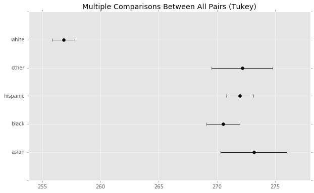

```python
from statsmodels.stats.multicomp import pairwise_tukeyhsd

tukey = pairwise_tukeyhsd(endog=sales,     # Data
                          groups=race,   # Groups
                          alpha=0.05)          # Significance level

tukey.plot_simultaneous()    # Plot group confidence intervals

tukey.summary()              # See test summary
```

### Correlation analysis

You can make use of Pandas built-in functions for correlation analysis or use stats functions

```python
import pandas as pd

X = pd.DataFrame({"A":[34,12,78,84,26], "B":[54,87,35,25,82], "C":[56,78,0,14,13], "D":[0,23,72,56,14], "E":[78,12,31,0,34]})
Y = pd.DataFrame({"A1":[45,24,65,65,65], "B1":[45,87,65,52,12], "C1":[98,52,32,32,12], "D1":[0,23,1,365,53], "E1":[24,12,65,3,65]})

pd.concat([X,Y], axis=1).corr(method="pearson")
```

|  | A | B | C | D | E | A1 | B1 | C1 | D1 | E1 |
| --- | --- | --- | --- | --- | --- | --- | --- | --- | --- | --- |
| A | 1.000000 | -0.956017 | -0.742974 | 0.836235 | -0.301064 | 0.713185 | 0.030675 | -0.266264 | 0.580956 | 0.016527 |
| B | -0.956017 | 1.000000 | 0.577688 | -0.686044 | 0.108499 | -0.592371 | -0.070546 | -0.019835 | -0.552312 | 0.140005 |
| C | -0.742974 | 0.577688 | 1.000000 | -0.641407 | 0.191284 | -0.970444 | 0.488012 | 0.661107 | -0.320539 | -0.582389 |
| D | 0.836235 | -0.686044 | -0.641407 | 1.000000 | -0.596940 | 0.487752 | 0.346860 | -0.508720 | 0.384165 | 0.129360 |
| E | -0.301064 | 0.108499 | 0.191284 | -0.596940 | 1.000000 | -0.074010 | -0.339427 | 0.683504 | -0.624039 | 0.286023 |
| A1 | 0.713185 | -0.592371 | -0.970444 | 0.487752 | -0.074010 | 1.000000 | -0.636047 | -0.557722 | 0.389749 | 0.506232 |
| B1 | 0.030675 | -0.070546 | 0.488012 | 0.346860 | -0.339427 | -0.636047 | 1.000000 | 0.283816 | -0.080727 | -0.473169 |
| C1 | -0.266264 | -0.019835 | 0.661107 | -0.508720 | 0.683504 | -0.557722 | 0.283816 | 1.000000 | -0.314818 | -0.442846 |
| D1 | 0.580956 | -0.552312 | -0.320539 | 0.384165 | -0.624039 | 0.389749 | -0.080727 | -0.314818 | 1.000000 | -0.547130 |
| E1 | 0.016527 | 0.140005 | -0.582389 | 0.129360 | 0.286023 | 0.506232 | -0.473169 | -0.442846 | -0.547130 | 1.000000 |

```python
pd.concat([X,Y], axis=1).corr(method="spearman")
```

|  | A | B | C | D | E | A1 | B1 | C1 | D1 | E1 |
| --- | --- | --- | --- | --- | --- | --- | --- | --- | --- | --- |
| A | 1.000000 | -1.000000 | -0.500000 | 0.500000 | -0.300000 | 0.670820 | -0.100000 | -0.153897 | 0.200000 | -0.205196 |
| B | -1.000000 | 1.000000 | 0.500000 | -0.500000 | 0.300000 | -0.670820 | 0.100000 | 0.153897 | -0.200000 | 0.205196 |
| C | -0.500000 | 0.500000 | 1.000000 | -0.500000 | -0.100000 | -0.894427 | 0.300000 | 0.718185 | -0.100000 | -0.666886 |
| D | 0.500000 | -0.500000 | -0.500000 | 1.000000 | -0.700000 | 0.447214 | 0.600000 | -0.359092 | 0.300000 | -0.051299 |
| E | -0.300000 | 0.300000 | -0.100000 | -0.700000 | 1.000000 | -0.111803 | -0.600000 | 0.205196 | -0.700000 | 0.666886 |
| A1 | 0.670820 | -0.670820 | -0.894427 | 0.447214 | -0.111803 | 1.000000 | -0.447214 | -0.802955 | 0.447214 | 0.344124 |
| B1 | -0.100000 | 0.100000 | 0.300000 | 0.600000 | -0.600000 | -0.447214 | 1.000000 | 0.359092 | -0.100000 | -0.359092 |
| C1 | -0.153897 | 0.153897 | 0.718185 | -0.359092 | 0.205196 | -0.802955 | 0.359092 | 1.000000 | -0.666886 | -0.394737 |
| D1 | 0.200000 | -0.200000 | -0.100000 | 0.300000 | -0.700000 | 0.447214 | -0.100000 | -0.666886 | 1.000000 | -0.410391 |
| E1 | -0.205196 | 0.205196 | -0.666886 | -0.051299 | 0.666886 | 0.344124 | -0.359092 | -0.394737 | -0.410391 | 1.000000 |

```python
a = np.array([[1, 2, 1, 3], [5, 3, 1, 8]], float)
c = np.corrcoef(a)
c
```

```
array([[ 1.        ,  0.72870505],
       [ 0.72870505,  1.        ]])
```

```python
a = np.array([1,2,3,4,5])
b = np.array([1,2,2,3,5])
stats.pearsonr(a,b)
```

```
(0.93831486325683633, 0.018219854743222446)
```

```python
a = np.array([1,2,3,4,5])
b = np.array([1,2,2,3,5])
stats.spearmanr(a,b)
```

```
SpearmanrResult(correlation=0.97467943448089644, pvalue=0.004818230468198537)
```